# Portafolio de derivados del Equipo 6

Registro consolidado y auditado de operaciones · 22 de septiembre al 7 de noviembre de 2026

Equipo 6 · Grupo 40 — Eduardo Ayala Saldaña (A01192714), Mariann Antonelli Morales Tobias (A01452078), Ulises Salinas López (A00814787)

Productos Derivados y Administración de Riesgos Corporativos · Dr. Raymundo Díaz Robles

# 1 Qué contiene este documento

El registro completo de las operaciones con derivados que el equipo ejecutó entre el 22 de septiembre y el 5 de noviembre de 2026, la estrategia que sustentó cada una, el desenlace de las que ya cerraron y la valuación de las que siguen vivas.

La característica que distingue a este reporte es que **las cifras están cuadradas contra los saldos de las plataformas**. No se afirma un resultado sin que la suma de las operaciones reproduzca el saldo observado. Donde el cuadre no es posible, se dice.

## 1.1 Las dos plataformas y por qué importa la distinción

Las operaciones se ejecutaron en dos simuladores con reglas, capitales y clases de activo distintas. Tratarlos como un solo libro produciría cifras sin sentido.

```r
plataformas <- data.frame(
  Plataforma = c("Investopedia", "CME Group Practice"),
  Capital = c("$1,000,000", "$100,000"),
  Instrumentos = c("Acciones y opciones sobre acciones",
                   "Futuros y opciones sobre futuros"),
  Multiplicador = c("100 por contrato",
                    "Varía: 50 el ES, 100 el oro, 1,000 el crudo, 100,000 el CAD"),
  Liquidacion = c("Entrega de acciones", "Efectivo o entrega del futuro"),
  stringsAsFactors = FALSE)
plataformas
```

| Plataforma | Capital | Instrumentos | Multiplicador | Liquidacion |
| --- | --- | --- | --- | --- |
| Investopedia | $1,000,000 | Acciones y opciones sobre acciones | 100 por contrato | Entrega de acciones |
| CME Group Practice | $100,000 | Futuros y opciones sobre futuros | Varía: 50 el ES, 100 el oro, 1,000 el crudo, 100,000 el CAD | Efectivo o entrega del futuro |

Un tercer entorno, **TradingView Paper Trading**, es también una cuenta de ejecución de papel (capital de $100,000, con posiciones y fills propios) y se documenta aparte en la sección 6. Además se usó para obtener cotizaciones y cadenas de opciones en las actividades de clase.

## 1.2 Los diferenciales alcistas: dónde está la pata vendida y qué acota el riesgo

El portafolio **no es exclusivamente de compras de opciones**. Los dos diferenciales alcistas que el equipo armó —el de oro de Eduardo y el de crudo de Ulises— incluyen una pata vendida. Esto tiene consecuencias de riesgo: una call vendida al descubierto tendría pérdida ilimitada, y lo que la acota en ambos casos es precisamente la call comprada de strike inferior. La estructura es la que limita el riesgo, no una política de no vender.

# 2 La auditoría de las cuentas

Antes de interpretar cualquier resultado, conviene establecer que las cifras son verificables. Esta sección reconstruye el saldo de cada cuenta desde las operaciones individuales.

## 2.1 Cuenta de Investopedia

```r
inv <- data.frame(
  Instrumento = c("AAPL acciones", "NVDA call 227.5 (9-oct)", "AAPL call 332.5 (16-oct)",
                  "SPY put 778 (23-oct)", "NVDA put 225 (23-oct)", "AAPL put 345 (25-sep)",
                  "SLV call 55 (16-oct)", "JPM call 335 (23-oct)", "AAPL put 320 (30-oct)",
                  "TLT put 78 (23-oct)", "SPY call 778 (23-oct)"),
  Costo   = c(33080, 592, 525, 459, 780, 580, 126, 640, 490, 450, 598),
  Ingreso = c(34615, 1498, 1320, 1131, 1430, 765, 44, 395, 82, 10, 115),
  stringsAsFactors = FALSE)
inv$PL      <- inv$Ingreso - inv$Costo
inv$Retorno <- inv$PL / inv$Costo * 100
inv_ord <- inv[order(-inv$PL), ]
data.frame(Instrumento = inv_ord$Instrumento,
           Costo   = usd(inv_ord$Costo),
           Ingreso = usd(inv_ord$Ingreso),
           `P&L`   = usd(inv_ord$PL),
           Retorno = pct(inv_ord$Retorno, 1),
           check.names = FALSE)
```

| Instrumento | Costo | Ingreso | P&L | Retorno |
| --- | --- | --- | --- | --- |
| AAPL acciones | $33,080 | $34,615 | $1,535 | 4.6% |
| NVDA call 227.5 (9-oct) | $592 | $1,498 | $906 | 153.0% |
| AAPL call 332.5 (16-oct) | $525 | $1,320 | $795 | 151.4% |
| SPY put 778 (23-oct) | $459 | $1,131 | $672 | 146.4% |
| NVDA put 225 (23-oct) | $780 | $1,430 | $650 | 83.3% |
| AAPL put 345 (25-sep) | $580 | $765 | $185 | 31.9% |
| SLV call 55 (16-oct) | $126 | $44 | -$82 | -65.1% |
| JPM call 335 (23-oct) | $640 | $395 | -$245 | -38.3% |
| AAPL put 320 (30-oct) | $490 | $82 | -$408 | -83.3% |
| TLT put 78 (23-oct) | $450 | $10 | -$440 | -97.8% |
| SPY call 778 (23-oct) | $598 | $115 | -$483 | -80.8% |

```r
SALDO_INV <- 1003085; CAP_INV <- 1000000
cat("Suma de las operaciones      ", usd(sum(inv$PL), 2), "\n")
```

```
## Suma de las operaciones       $3,085.00
```

```r
cat("Variación observada del saldo", usd(SALDO_INV - CAP_INV, 2), "\n")
```

```
## Variación observada del saldo $3,085.00
```

```r
cat("Residuo                      ", usd(sum(inv$PL) - (SALDO_INV - CAP_INV), 2), "\n")
```

```
## Residuo                       $0.00
```

El residuo es cero. Las once posiciones cerradas explican la totalidad del movimiento de la cuenta. Los símbolos del historial siguen la convención abreviada de la OCC —`TICKER` + año + día + letra de mes + strike—, donde la letra codifica simultáneamente el mes y el tipo: `A` a `L` son calls de enero a diciembre y `M` a `X` son puts. Así `AAPL2616J332.5` es una call de Apple con strike 332.50 que vence el 16 de octubre de 2026.

## 2.2 Cuenta de CME Group

```r
cme <- data.frame(
  Instrumento = c("Call ES 7830 (S&P 500 e-mini)",
                  "Call GC 4400 oro (pata vendida)",
                  "Call GC 4200 oro (pata comprada)"),
  Apertura = c("5-oct a 58.00", "29-sep a 31.00", "29-sep a 100.50"),
  Cierre   = c("15-oct a 0.05", "27-oct a 0.10", "27-oct a 0.20"),
  Mult     = c(50, 100, 100),
  Signo    = c(1, -1, 1),
  P_abre   = c(58.00, 31.00, 100.50),
  P_cierra = c(0.05, 0.10, 0.20),
  Reportado = c(-2897.5, 3090.0, -10030.0),
  stringsAsFactors = FALSE)
cme$Calculado <- cme$Signo * (cme$P_cierra - cme$P_abre) * cme$Mult
data.frame(Instrumento = cme$Instrumento, Apertura = cme$Apertura, Cierre = cme$Cierre,
           Calculado = usd(cme$Calculado, 2),
           `Reportado por CME` = usd(cme$Reportado, 2),
           Diferencia = usd(cme$Calculado - cme$Reportado, 2),
           check.names = FALSE)
```

| Instrumento | Apertura | Cierre | Calculado | Reportado por CME | Diferencia |
| --- | --- | --- | --- | --- | --- |
| Call ES 7830 (S&P 500 e-mini) | 5-oct a 58.00 | 15-oct a 0.05 | -$2,897.50 | -$2,897.50 | $0.00 |
| Call GC 4400 oro (pata vendida) | 29-sep a 31.00 | 27-oct a 0.10 | $3,090.00 | $3,090.00 | $0.00 |
| Call GC 4200 oro (pata comprada) | 29-sep a 100.50 | 27-oct a 0.20 | -$10,030.00 | -$10,030.00 | $0.00 |

```r
SALDO_CME <- 90162.50
cat("P&L realizado acumulado ", usd(sum(cme$Calculado), 2), "\n")
```

```
## P&L realizado acumulado  -$9,837.50
```

```r
cat("Saldo observado hoy     ", usd(SALDO_CME, 2), "\n")
```

```
## Saldo observado hoy      $90,162.50
```

```r
cat("Capital inicial despejado", usd(SALDO_CME - sum(cme$Calculado), 2), "\n")
```

```
## Capital inicial despejado $100,000.00
```

El capital inicial que se despeja es exactamente cien mil dólares, que es el monto con que abre la plataforma. Las tres operaciones explican la totalidad de la pérdida. Ningún dólar queda sin asignar en ninguna de las dos cuentas.

# 3 El hallazgo central

Los dos libros pertenecen al mismo operador y cubren el mismo periodo. Los resultados son opuestos.

```r
contraste <- data.frame(
  Libro = c("Investopedia", "CME Group"),
  Capital_desplegado = c(sum(inv$Costo), 58*50 + (100.5-31.0)*100),
  Resultado = c(sum(inv$PL), sum(cme$Calculado)),
  stringsAsFactors = FALSE)
contraste$Retorno <- contraste$Resultado / contraste$Capital_desplegado * 100
data.frame(Libro = contraste$Libro,
           `Capital desplegado` = usd(contraste$Capital_desplegado),
           Resultado = usd(contraste$Resultado),
           Retorno = pct(contraste$Retorno, 1),
           check.names = FALSE)
```

| Libro | Capital desplegado | Resultado | Retorno |
| --- | --- | --- | --- |
| Investopedia | $38,320 | $3,085 | 8.1% |
| CME Group | $9,850 | -$9,838 | -99.9% |

La diferencia no la explica el mercado. La explica **cómo se cerraron las posiciones**.

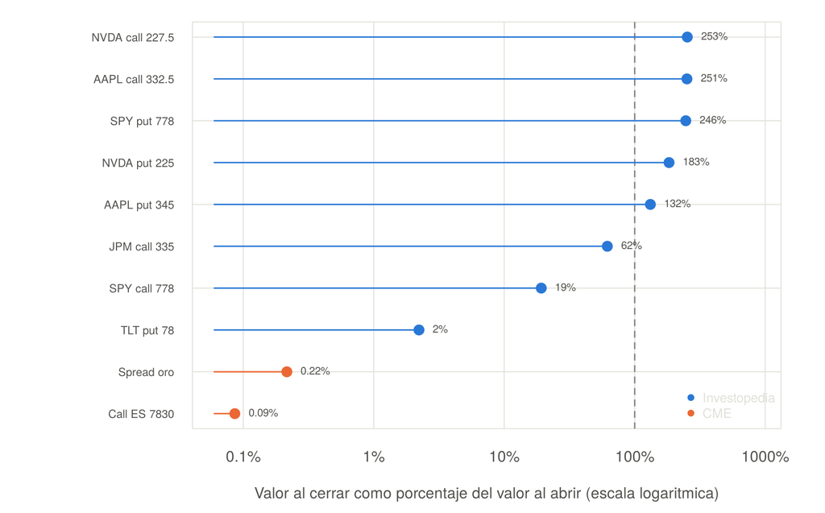

```r
ten <- data.frame(
  pos = c("AAPL put 345", "NVDA call 227.5", "AAPL call 332.5", "SPY put 778",
          "NVDA put 225", "SPY call 778", "TLT put 78", "JPM call 335",
          "Call ES 7830", "Spread oro"),
  dias = c(1, 5, 7, 1, 1, 7, 7, 7, 10, 28),
  libro = c(rep("Investopedia", 8), "CME", "CME"),
  cierre = c(7.65, 14.98, 13.20, 11.31, 7.15, 1.15, 0.01, 3.95, 0.05, 0.15),
  apertura = c(5.80, 5.92, 5.25, 4.59, 3.90, 5.98, 0.45, 6.40, 58.00, 69.50),
  stringsAsFactors = FALSE)
ten$frac <- ten$cierre / ten$apertura * 100
ten <- ten[order(ten$frac), ]
n <- nrow(ten)
par(mar = c(4.6, 10.5, 1.2, 2.4), las = 1, col.axis = TINTA, col.lab = TINTA, fg = REJILLA)
col <- ifelse(ten$libro == "CME", NARANJA, AZUL)
# Escala logaritmica: los valores recorren tres ordenes de magnitud, de 0.09%
# a 253%. En escala lineal las posiciones de CME serian invisibles, que es
# justo la informacion que el grafico debe transmitir.
plot(ten$frac, seq_len(n), log = "x", type = "n", yaxt = "n", xaxt = "n",
     xlim = c(0.06, 900),
     xlab = "Valor al cerrar como porcentaje del valor al abrir (escala logaritmica)",
     ylab = "", panel.first = grid(col = REJILLA, lty = 1))
axis(1, at = c(0.1, 1, 10, 100, 1000),
     labels = c("0.1%", "1%", "10%", "100%", "1000%"), tick = FALSE)
abline(v = 100, col = GRIS, lty = 2, lwd = 1.5)
segments(0.06, seq_len(n), ten$frac, seq_len(n), col = col, lwd = 1.5)
points(ten$frac, seq_len(n), pch = 19, col = col, cex = 1.45)
axis(2, at = seq_len(n), labels = ten$pos, cex.axis = 0.74, tick = FALSE)
etq <- ifelse(ten$frac < 1, sprintf("%.2f%%", ten$frac), sprintf("%.0f%%", ten$frac))
text(ten$frac, seq_len(n), etq, pos = 4, offset = 0.75, cex = 0.7, col = TINTA)
legend("bottomright", c("Investopedia", "CME"), col = c(AZUL, NARANJA),
       pch = 19, bty = "n", cex = 0.85)
```

Las tres posiciones de CME se cerraron en **0.05, 0.10 y 0.20**: precios que no son una salida sino el reconocimiento de que ya no quedaba nada por rescatar. En Investopedia las posiciones se cortaron mientras conservaban valor, en plazos de uno a siete días.

Una opción es un activo que se deteriora por construcción. Sostenerla hasta que el valor temporal se agota convierte una apuesta probabilística en una binaria y entrega íntegra la prima al vendedor. El contraste entre los dos libros del mismo operador, en el mismo periodo y con el mismo criterio de selección, aísla ese efecto mejor que cualquier ejemplo de libro de texto.

# 4 Las estrategias

El exportador de cada plataforma lista operaciones sueltas. Pero dos posiciones abiertas el mismo día sobre el mismo subyacente no son independientes: forman una estructura con perfil de riesgo propio. Esta sección las reconstruye.

## 4.1 Protective put: el mismo instrumento, dos desenlaces

El equipo armó esta estrategia dos veces sobre la misma acción. Eduardo la ejecutó el 30 de septiembre; Ulises la documentó en su Tarea 2. En un caso la acción subió, en el otro bajó. Juntos agotan la enseñanza del protective put.

```r
pp <- data.frame(
  Concepto = c("Acciones", "Precio de compra", "Precio de salida", "Strike del put",
               "Prima pagada", "Prima de salida"),
  Eduardo = c("100 AAPL", "330.80", "346.15", "320.00", "4.90", "0.82"),
  Ulises  = c("200 AAPL", "340.37", "332.89", "342.50", "7.50", "9.70"),
  stringsAsFactors = FALSE)
pp
```

| Concepto | Eduardo | Ulises |
| --- | --- | --- |
| Acciones | 100 AAPL | 200 AAPL |
| Precio de compra | 330.80 | 340.37 |
| Precio de salida | 346.15 | 332.89 |
| Strike del put | 320.00 | 342.50 |
| Prima pagada | 4.90 | 7.50 |
| Prima de salida | 0.82 | 9.70 |

```r
e_acc <- (346.15 - 330.80) * 100;  e_put <- (0.82 - 4.90) * 100
u_acc <- (332.89 - 340.37) * 200;  u_put <- (9.70 - 7.50) * 200
resumen_pp <- data.frame(
  Componente = c("Acciones", "Put (el seguro)", "Resultado cubierto", "Resultado sin cubrir"),
  Eduardo = usd(c(e_acc, e_put, e_acc + e_put, e_acc)),
  Ulises  = usd(c(u_acc, u_put, u_acc + u_put, u_acc)),
  stringsAsFactors = FALSE)
resumen_pp
```

| Componente | Eduardo | Ulises |
| --- | --- | --- |
| Acciones | $1,535 | -$1,496 |
| Put (el seguro) | -$408 | $440 |
| Resultado cubierto | $1,127 | -$1,056 |
| Resultado sin cubrir | $1,535 | -$1,496 |

En el caso de Eduardo la acción subió 15.35 dólares por título. El put nunca se necesitó, expiró casi sin valor y costó $408, equivalente al 26.6% de la ganancia de la acción. **El seguro se paga aunque no haya siniestro.**

En el caso de Ulises la acción cayó y el put sí operó. Conviene descomponer su prima para ver cuánto de la cobertura llegó efectivamente al bolsillo.

```r
S0 <- 340.37; S1 <- 332.89; K <- 342.50; P0 <- 7.50; P1 <- 9.70
int0 <- max(K - S0, 0); int1 <- max(K - S1, 0)
desc <- data.frame(
  Componente = c("Precio de la acción", "Prima del put",
                 "   de la cual, valor intrínseco", "   de la cual, valor temporal"),
  `Al comprar` = c(S0, P0, int0, P0 - int0),
  Hoy = c(S1, P1, int1, P1 - int1),
  Cambio = c(S1 - S0, P1 - P0, int1 - int0, (P1 - int1) - (P0 - int0)),
  check.names = FALSE)
desc
```

| Componente | Al comprar | Hoy | Cambio |
| --- | --- | --- | --- |
| Precio de la acción | 340.37 | 332.89 | -7.48 |
| Prima del put | 7.50 | 9.70 | 2.20 |
| de la cual, valor intrínseco | 2.13 | 9.61 | 7.48 |
| de la cual, valor temporal | 5.37 | 0.09 | -5.28 |

```r
cat("\nLa acción cayó", sprintf("%.2f", S0 - S1), "por título.\n")
```

```
##
## La acción cayó 7.48 por título.
```

```r
cat("El valor intrínseco subió", sprintf("%.2f", int1 - int0),
    ": capturó la caída uno a uno.\n")
```

```
## El valor intrínseco subió 7.48 : capturó la caída uno a uno.
```

```r
cat("El valor temporal se consumió", sprintf("%.2f", (P0 - int0) - (P1 - int1)),
    ", es decir", pct(((P0-int0)-(P1-int1))/(int1-int0)*100, 0), "de esa ganancia.\n")
```

```
## El valor temporal se consumió 5.28 , es decir 71% de esa ganancia.
```

```r
cat("Eficacia neta de la cobertura:", pct((P1 - P0)/(S0 - S1)*100, 1), "\n")
```

```
## Eficacia neta de la cobertura: 29.4%
```

El put dentro del dinero capturó la caída de la acción **uno a uno en valor intrínseco**, que es exactamente lo que la teoría predice. Pero el valor temporal se evaporó en el camino y devoró el 71 % de esa ganancia. La cobertura funcionó en dirección y falló en magnitud, y la causa no fue un error de ejecución sino la naturaleza del instrumento.

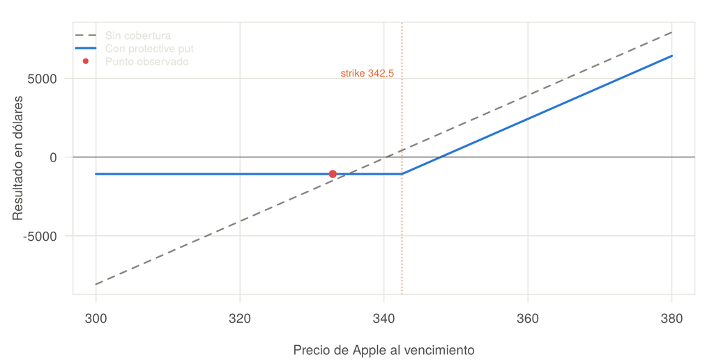

```r
panel()
ST <- seq(300, 380, by = 0.5)
sin_cob <- (ST - S0) * 200
con_cob <- (ST - S0) * 200 + (pmax(K - ST, 0) - P0) * 200
plot(ST, sin_cob, type = "l", col = GRIS, lwd = 2, lty = 2,
     xlab = "Precio de Apple al vencimiento", ylab = "Resultado en dólares",
     panel.first = grid(col = REJILLA, lty = 1))
lines(ST, con_cob, col = AZUL, lwd = 2.6)
abline(h = 0, col = TINTA); abline(v = K, col = NARANJA, lty = 3)
points(S1, (S1 - S0)*200 + (max(K - S1, 0) - P0)*200, pch = 19, col = ROJO, cex = 1.2)
text(K, max(con_cob)*0.82, paste0("strike ", K), col = NARANJA, cex = 0.78, pos = 2)
legend("topleft", c("Sin cobertura", "Con protective put", "Punto observado"),
       col = c(GRIS, AZUL, ROJO), lwd = c(2, 2.6, NA), lty = c(2, 1, NA),
       pch = c(NA, NA, 19), bty = "n", cex = 0.82)
```

El perfil muestra lo esencial: por debajo del strike la pérdida queda acotada, y ese piso se compra desplazando toda la curva hacia abajo por el monto de la prima. No hay protección gratuita.

## 4.2 Straddle sobre el S&P 500

El 13 de octubre se compraron **una call y un put de SPY con el mismo strike 778 y el mismo vencimiento**, en la misma sesión. No son dos apuestas direccionales opuestas que se anulan: son una sola posición cuyo subyacente es la magnitud del movimiento, no su dirección.

```r
c_c <- 5.98; c_v <- 1.15; p_c <- 4.59; p_v <- 11.31
strad <- data.frame(
  Pata = c("Call 778", "Put 778", "Straddle"),
  Costo = usd(c(c_c, p_c, c_c + p_c) * 100),
  Ingreso = usd(c(c_v, p_v, c_v + p_v) * 100),
  `P&L` = usd(c(c_v - c_c, p_v - p_c, (c_v + p_v) - (c_c + p_c)) * 100),
  check.names = FALSE)
strad
```

| Pata | Costo | Ingreso | P&L |
| --- | --- | --- | --- |
| Call 778 | $598 | $115 | -$483 |
| Put 778 | $459 | $1,131 | $672 |
| Straddle | $1,057 | $1,246 | $189 |

```r
cat("\nRetorno sobre la prima:", pct(((c_v + p_v)/(c_c + p_c) - 1) * 100, 1), "\n")
```

```
##
## Retorno sobre la prima: 17.9%
```

```r
cat("Puntos de equilibrio al vencimiento:", sprintf("%.2f", 778 - (c_c + p_c)),
    "y", sprintf("%.2f", 778 + (c_c + p_c)), "\n")
```

```
## Puntos de equilibrio al vencimiento: 767.43 y 788.57
```

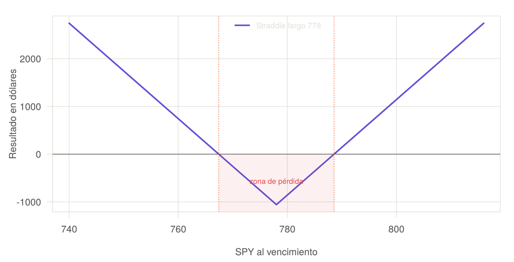

```r
panel()
ST <- seq(740, 816, by = 0.5)
prima <- c_c + p_c
pago <- (pmax(ST - 778, 0) + pmax(778 - ST, 0) - prima) * 100
plot(ST, pago, type = "l", col = VIOLETA, lwd = 2.6,
     xlab = "SPY al vencimiento", ylab = "Resultado en dólares",
     panel.first = grid(col = REJILLA, lty = 1))
abline(h = 0, col = TINTA)
abline(v = c(778 - prima, 778 + prima), col = NARANJA, lty = 3)
polygon(c(778 - prima, 778 + prima, 778 + prima, 778 - prima),
        c(-1e4, -1e4, 0, 0), col = adjustcolor(ROJO, 0.08), border = NA)
text(778, -prima*100*0.55, "zona de pérdida", col = ROJO, cex = 0.78)
legend("top", "Straddle largo 778", col = VIOLETA, lwd = 2.6, bty = "n", cex = 0.82)
```

El mercado cayó y el put financió con holgura a la call. La estructura no necesitaba acertar la dirección; le bastaba con que el movimiento excediera la prima combinada de 10.57 dólares. Es la única posición del portafolio cuya tesis es explícitamente sobre volatilidad y no sobre precio.

## 4.3 Diferenciales alcistas: oro y crudo

Ambos integrantes armaron un bull call spread, sobre subyacentes distintos y con calibraciones muy distintas. La comparación revela el intercambio fundamental de la estructura.

```r
sp <- data.frame(
  Concepto = c("Subyacente al armar", "Strike comprado", "Prima pagada", "Strike vendido",
               "Prima cobrada", "Débito neto por unidad", "Contratos", "Desembolso",
               "Ancho del diferencial", "Ganancia máxima", "Beneficio / riesgo",
               "Punto de equilibrio", "Movimiento necesario", "Débito / ancho"),
  `Eduardo · oro OG nov-26` = c("4,207.90", "4,200.00", "100.50", "4,400.00", "31.00",
                                "69.50", "1", "$6,950", "200.00", "$13,050", "1.88 a 1",
                                "4,269.50", "+1.46%", "35%"),
  `Ulises · crudo CL oct-26` = c("88.75", "88.75", "2.76", "90.75", "1.76",
                                 "1.00", "5", "$5,000", "2.00", "$5,000", "1.00 a 1",
                                 "89.75", "+1.13%", "50%"),
  check.names = FALSE, stringsAsFactors = FALSE)
sp
```

| Concepto | Eduardo · oro OG nov-26 | Ulises · crudo CL oct-26 |
| --- | --- | --- |
| Subyacente al armar | 4,207.90 | 88.75 |
| Strike comprado | 4,200.00 | 88.75 |
| Prima pagada | 100.50 | 2.76 |
| Strike vendido | 4,400.00 | 90.75 |
| Prima cobrada | 31.00 | 1.76 |
| Débito neto por unidad | 69.50 | 1.00 |
| Contratos | 1 | 5 |
| Desembolso | $6,950 | $5,000 |
| Ancho del diferencial | 200.00 | 2.00 |
| Ganancia máxima | $13,050 | $5,000 |
| Beneficio / riesgo | 1.88 a 1 | 1.00 a 1 |
| Punto de equilibrio | 4,269.50 | 89.75 |
| Movimiento necesario | +1.46% | +1.13% |
| Débito / ancho | 35% | 50% |

El diferencial de oro paga 1.88 dólares por cada dólar arriesgado; el de crudo paga 1.00. La diferencia no proviene de la habilidad sino de **dónde se colocaron los strikes respecto al precio corriente**. Eduardo pagó el 35 % del ancho y necesitaba un alza de 1.46 %; Ulises pagó el 50 % y necesitaba 1.13 %. Es el intercambio de siempre: cuanto más cerca del dinero se arma la estructura, más probable es acertar y menos paga el acierto.

### 4.3.1 El desenlace del diferencial de oro

```r
oro <- data.frame(
  Pata = c("Compra call 4200", "Vende call 4400", "Diferencial"),
  Apertura = c("100.50", "31.00", "69.50 de débito"),
  Cierre = c("0.20", "0.10", "0.10 de crédito"),
  `P&L` = usd(c(-10030, 3090, -6940)),
  check.names = FALSE, stringsAsFactors = FALSE)
oro
```

| Pata | Apertura | Cierre | P&L |
| --- | --- | --- | --- |
| Compra call 4200 | 100.50 | 0.20 | -$10,030 |
| Vende call 4400 | 31.00 | 0.10 | $3,090 |
| Diferencial | 69.50 de débito | 0.10 de crédito | -$6,940 |

```r
deb_oro <- (100.5 - 31.0) * 100
cat("\nPérdida máxima teórica:", usd(-deb_oro, 2), "\n")
```

```
##
## Pérdida máxima teórica: -$6,950.00
```

```r
cat("Resultado efectivo:     ", usd(-6940, 2), "\n")
```

```
## Resultado efectivo:      -$6,940.00
```

```r
cat("Fracción realizada de la pérdida máxima:", pct(6940/deb_oro*100, 2), "\n")
```

```
## Fracción realizada de la pérdida máxima: 99.86%
```

```r
cat("\nSin la pata vendida, la pérdida habría sido", usd(-10030), "\n")
```

```
##
## Sin la pata vendida, la pérdida habría sido -$10,030
```

```r
cat("El diferencial la redujo", pct((1 - 6940/10030) * 100, 1), "\n")
```

```
## El diferencial la redujo 30.8%
```

Las dos patas se cerraron el 27 de octubre en 0.20 y 0.10, lo que significa que el oro terminó por debajo de 4,200: no solo no alcanzó el equilibrio de 4,269.50, sino que retrocedió bajo el strike inferior. La estructura realizó el 99.86 % de su pérdida máxima.

Conviene no leer eso como un fracaso del instrumento. **La pata vendida hizo exactamente su trabajo**: aportó 3,090 dólares que amortiguaron la pérdida de la pata comprada en un 30.8 %. Un diferencial no mejora la puntería direccional; abarata la apuesta a cambio de techar la ganancia. Cumplió con lo que promete.

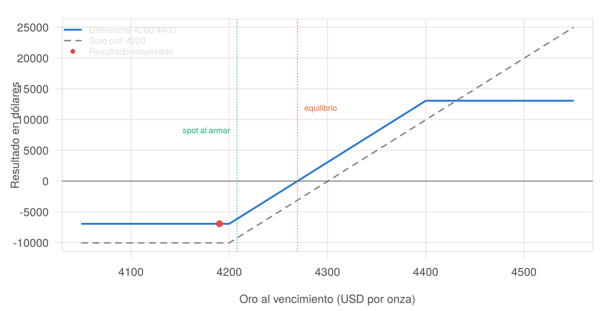

```r
panel()
ST <- seq(4050, 4550, by = 1)
pago <- (pmax(ST - 4200, 0) - pmax(ST - 4400, 0) - 69.50) * 100
solo <- (pmax(ST - 4200, 0) - 100.50) * 100
plot(ST, pago, type = "l", col = AZUL, lwd = 2.6, ylim = range(c(pago, solo)),
     xlab = "Oro al vencimiento (USD por onza)", ylab = "Resultado en dólares",
     panel.first = grid(col = REJILLA, lty = 1))
lines(ST, solo, col = GRIS, lwd = 2, lty = 2)
abline(h = 0, col = TINTA); abline(v = 4269.50, col = NARANJA, lty = 3)
abline(v = 4207.90, col = VERDE, lty = 3)
points(4190, -6940, pch = 19, col = ROJO, cex = 1.2)
text(4269.5, max(pago)*0.9, "equilibrio", col = NARANJA, cex = 0.72, pos = 4)
text(4207.9, max(pago)*0.62, "spot al armar", col = VERDE, cex = 0.72, pos = 2)
legend("topleft", c("Diferencial 4200/4400", "Solo call 4200", "Resultado observado"),
       col = c(AZUL, GRIS, ROJO), lwd = c(2.6, 2, NA), lty = c(1, 2, NA),
       pch = c(NA, NA, 19), bty = "n", cex = 0.8)
```

La línea gris muestra lo que habría ocurrido comprando únicamente la call de 4200. A la izquierda del gráfico —que es donde terminó el oro— corre por debajo de la azul: ahí está, gráficamente, el beneficio de haber vendido la call superior.

# 5 El ciclo del 5 de noviembre: primer diseño de la cobertura

Las operaciones de ese ciclo abandonan la lógica de las anteriores. En lugar de expresar una vista direccional sobre acciones o materias primas, **replican con derivados listados dos exposiciones reales del balance de Walmart**, que es la empresa del proyecto de investigación. El portafolio y el estudio de caso dejan de ser dos entregables separados.

## 5.1 Las dos exposiciones que se cubren

```r
exp <- data.frame(
  Exposicion = c("Deuda emitida en dólares canadienses",
                 "Swaps de tasa que reciben fijo y pagan variable"),
  Monto = c("C$5,000 millones", "$4,771 millones nocionales"),
  Fuente = c("Emisión de octubre de 2026", "Nota 7 del reporte anual 10-K"),
  Riesgo = c("Si el CAD se aprecia, la deuda cuesta más en dólares",
             "Si las tasas suben, el swap pierde valor (FV actual: -$411 millones)"),
  Cobertura = c("Call sobre el futuro del dólar canadiense (6C)",
                "Put sobre el futuro de la nota del Tesoro a 10 años (ZN)"),
  stringsAsFactors = FALSE)
exp
```

| Exposicion | Monto | Fuente | Riesgo | Cobertura |
| --- | --- | --- | --- | --- |
| Deuda emitida en dólares canadienses | C$5,000 millones | Emisión de octubre de 2026 | Si el CAD se aprecia, la deuda cuesta más en dólares | Call sobre el futuro del dólar canadiense (6C) |
| Swaps de tasa que reciben fijo y pagan variable | $4,771 millones nocionales | Nota 7 del reporte anual 10-K | Si las tasas suben, el swap pierde valor (FV actual: -$411 millones) | Put sobre el futuro de la nota del Tesoro a 10 años (ZN) |

Walmart debe dólares canadienses en el futuro, de modo que está estructuralmente corto esa divisa y para cubrirse tendría que comprarla: una call sobre 6C es esa compra. En el libro de tasas la empresa recibe fijo y paga variable, posición que pierde cuando los rendimientos suben —el valor razonable negativo de 411 millones lo confirma—, y un put sobre ZN es el primo bursátil del T-lock que el reporte del proyecto recomienda en el mercado extrabursátil.

## 5.2 Parámetros de ejecución

```r
viv <- data.frame(
  Posicion = c("Call 6CZ6 strike 0.715", "Put ZNZ6 strike 107.25"),
  Vencimiento = c("20-nov-2026", "20-nov-2026"),
  Contratos = c(10, 10),
  Subyacente = c(0.7145, 107.3172),
  Prima = c(0.0026, 0.546875),
  Multiplicador = c(100000, 1000),
  IV = c(4.53, 6.63),
  Delta = c(0.471, -0.478),
  stringsAsFactors = FALSE)
viv$Desembolso <- viv$Prima * viv$Multiplicador * viv$Contratos
data.frame(Posición = viv$Posicion, Vence = viv$Vencimiento, Contratos = viv$Contratos,
           Subyacente = viv$Subyacente, Prima = viv$Prima,
           `IV` = pct(viv$IV, 2), Delta = viv$Delta,
           Desembolso = usd(viv$Desembolso), check.names = FALSE)
```

| Posición | Vence | Contratos | Subyacente | Prima | IV | Delta | Desembolso |
| --- | --- | --- | --- | --- | --- | --- | --- |
| Call 6CZ6 strike 0.715 | 20-nov-2026 | 10 | 0.7145 | 0.002600 | 4.53% | 0.471 | $2,600 |
| Put ZNZ6 strike 107.25 | 20-nov-2026 | 10 | 107.3172 | 0.546875 | 6.63% | -0.478 | $5,469 |

```r
cat("\nPrima total comprometida:", usd(sum(viv$Desembolso)), "\n")
```

```
##
## Prima total comprometida: $8,069
```

```r
cat("Sobre el saldo de la cuenta:", pct(sum(viv$Desembolso)/90162.50*100, 2), "\n")
```

```
## Sobre el saldo de la cuenta: 8.95%
```

```r
cat("Pérdida máxima posible:", usd(-sum(viv$Desembolso)),
    "— no hay patas vendidas al descubierto.\n")
```

```
## Pérdida máxima posible: -$8,069 — no hay patas vendidas al descubierto.
```

Una nota de coherencia que vale registrar: el futuro cotiza en **0.7145 dólares por dólar canadiense**, cuyo inverso es **1.3996 USD/CAD**. El análisis del swap cross-currency del proyecto de investigación emplea 1.4008. La diferencia es de nueve centésimas de punto porcentual, lo que confirma que los parámetros del estudio de caso están calibrados contra el mercado vigente.

## 5.3 Por qué estas dos posiciones no son la misma apuesta

El ciclo anterior del equipo acumuló ocho posiciones que, vistas de cerca, expresaban una sola vista macroeconómica. Era concentración disfrazada de diversificación. Estas dos no lo son, y conviene demostrarlo en lugar de afirmarlo.

Si los rendimientos estadounidenses suben, el diferencial de tasas tiende a fortalecer al dólar, lo que deprime al dólar canadiense. El put de ZN gana en ese escenario y la call de 6C pierde. La relación entre ambas patas es inversa por construcción económica, no por casualidad.

```r
bs_call <- function(F, K, T, r, s) {
  d1 <- (log(F/K) + 0.5*s^2*T)/(s*sqrt(T)); d2 <- d1 - s*sqrt(T)
  exp(-r*T)*(F*pnorm(d1) - K*pnorm(d2)) }
bs_put <- function(F, K, T, r, s) {
  d1 <- (log(F/K) + 0.5*s^2*T)/(s*sqrt(T)); d2 <- d1 - s*sqrt(T)
  exp(-r*T)*(K*pnorm(-d2) - F*pnorm(-d1)) }

RF <- 0.0394; T1 <- 8.32/365        # plazo remanente al corte del 12-nov
COSTO <- sum(viv$Desembolso)
mov_cad  <- c(-0.015, -0.0075, 0, 0.0075, 0.015)
mov_bono <- c(-1.5, -0.75, 0, 0.75, 1.5)

M <- outer(mov_cad, mov_bono, Vectorize(function(mc, mb) {
  vc <- bs_call(0.7145*(1+mc), 0.715, T1, RF, 0.0453) * 100000 * 10
  vz <- bs_put(107.3172 + mb, 107.25, T1, RF, 0.0663) * 1000 * 10
  vc + vz - COSTO }))
dimnames(M) <- list(paste0("CAD ", sprintf("%+.2f", mov_cad*100), "%"),
                    paste0("bono ", sprintf("%+.2f", mov_bono)))
M_tab <- as.data.frame(apply(M, c(1,2), function(x) usd(x)))
M_tab
```

|  | bono -1.50 | bono -0.75 | bono +0.00 | bono +0.75 | bono +1.50 |
| --- | --- | --- | --- | --- | --- |
| CAD -1.50% | $6,705 | $465 | -$4,099 | -$6,660 | -$7,697 |
| CAD -0.75% | $6,959 | $719 | -$3,844 | -$6,405 | -$7,442 |
| CAD +0.00% | $8,397 | $2,156 | -$2,407 | -$4,968 | -$6,005 |
| CAD +0.75% | $11,959 | $5,718 | $1,155 | -$1,406 | -$2,443 |
| CAD +1.50% | $16,931 | $10,690 | $6,127 | $3,566 | $2,529 |

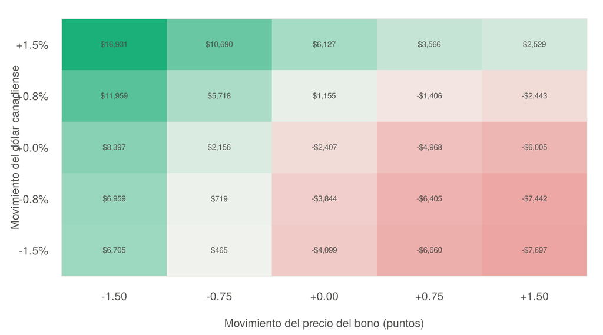

```r
panel()
rng <- max(abs(M))
cols <- colorRampPalette(c(ROJO, "#f5f4f0", VERDE))(101)
image(seq_along(mov_bono), seq_along(mov_cad), t(M), col = cols,
      zlim = c(-rng, rng), axes = FALSE, xlab = "Movimiento del precio del bono (puntos)",
      ylab = "Movimiento del dólar canadiense")
axis(1, at = seq_along(mov_bono), labels = sprintf("%+.2f", mov_bono), tick = FALSE)
axis(2, at = seq_along(mov_cad), labels = sprintf("%+.1f%%", mov_cad*100), tick = FALSE)
for (i in seq_along(mov_cad)) for (j in seq_along(mov_bono))
  text(j, i, usd(M[i, j]), cex = 0.7, col = TINTA)
box(col = REJILLA)
```

Las cuatro esquinas de la matriz son los cuatro regímenes posibles:

```r
reg <- data.frame(
  Régimen = c("Reflación: tasas suben, dólar se debilita",
              "Fed restrictiva: tasas suben, dólar se fortalece",
              "Fed acomodaticia: tasas bajan, dólar se debilita",
              "Aversión al riesgo: tasas bajan, dólar se fortalece"),
  `Call 6C` = usd(c(7642, -2583, 7642, -2583)),
  `Put ZN` = usd(c(9288, 9288, -5114, -5114)),
  Total = usd(c(16931, 6705, 2529, -7697)),
  check.names = FALSE, stringsAsFactors = FALSE)
reg
```

| Régimen | Call 6C | Put ZN | Total |
| --- | --- | --- | --- |
| Reflación: tasas suben, dólar se debilita | $7,642 | $9,288 | $16,931 |
| Fed restrictiva: tasas suben, dólar se fortalece | -$2,583 | $9,288 | $6,705 |
| Fed acomodaticia: tasas bajan, dólar se debilita | $7,642 | -$5,114 | $2,529 |
| Aversión al riesgo: tasas bajan, dólar se fortalece | -$2,583 | -$5,114 | -$7,697 |

Solo el cuarto régimen castiga a las dos patas simultáneamente, y exige una combinación particular: que el dólar se fortalezca mientras los rendimientos caen, que es el patrón de una fuga hacia la calidad. En los dos regímenes intermedios una pata financia a la otra. Eso es cobertura; lo del ciclo anterior era acumulación.

## Estado al 9 de noviembre

Las dos posiciones estaban en la cuenta de CME Practice de Eduardo y se cerraron el 9 de noviembre por la mañana (historial de transacciones de CME). Ambas fueron compras de 10 contratos con órdenes límite GTC:

| Posición | Apertura (5-nov) | Cierre (9-nov) | P&L realizado |
| --- | --- | --- | --- |
| Put ZNA6 107.25 | 5:10 pm, a 0.546875 | 8:41 am, a 0.4375 | -$1,093.75 |
| Call 6C66 0.715 | 6:08 pm, a 0.0026 | 8:40 am, a 0.0005 | -$2,100.00 |

El P&L realizado total es de -$3,193.75, el 39.6 % de la prima de $8,068.75. Antes del cierre, a las 8:23 am, el P&L no realizado era de -$3,350. El futuro del dólar canadiense pasó de 0.7145 a 0.7094 (-0.7 %) al 8 de noviembre, así que el call perdió el 81 % de su prima y el put el 20 %. El resultado cae dentro del rango de pérdidas que marcaba la matriz y queda lejos de la pérdida máxima.

# 6 Las cuentas: del equipo y las individuales

Esta sección completa el consolidado con las cuentas donde se ejecutó el trabajo, y aclara dos puntos: TradingView Paper Trading tiene cuenta de ejecución propia, y las posiciones del ciclo III sí se ejecutaron.

El trabajo es de **dos tipos**. Las Tareas 1 a 3 son movimientos individuales: cada integrante operó en su propia cuenta. Las Tareas 4 a 7 son trabajo en equipo, que se ejecutó en las cuentas de Mariann: las posiciones del 16 de octubre y el ciclo III del 18 de diciembre. El ciclo del 5 de noviembre en CME (put ZN y call 6C, 10 contratos cada uno) está en la cuenta de Eduardo, y la cobertura semanal de la sección 7 es un diseño que no se envió.

| Cuenta | Plataforma | Tipo | Qué contiene | Estado |
| --- | --- | --- | --- | --- |
| **Equipo** (operada en las cuentas de Mariann) | Investopedia, CME Practice y TradingView Paper Trading | Equipo, Tareas 4 a 7 | Estructuras del 16-oct y ciclo III (18-dic) | Secciones 6.1 y 6.2 |
| **Mariann** | Investopedia | Individual, Tareas 1 a 3 | Protective put, bull spread y valuación con Black-Scholes | $989,318.90, lugar 18 de 22 |
| **Eduardo** | Investopedia | Individual | JPM, SPY, NVDA y TLT (libro auditado en la sección 2). En CME Practice, además, el ciclo del 5-nov: 10 calls 6C y 10 puts ZN (sección 5) | $1,003,085, lugar 2 de 22 |
| **Ulises** | Investopedia | Individual | AAPL: compras de opciones del 24-sep y venta de 200 acciones del 5-nov | $1,003,845, lugar 3 de 22 |

Como el historial de Mariann mezcla ambos tipos, las tablas siguientes indican el **origen** de cada posición. Las capturas de las Tareas 6 y 7 muestran que TradingView tiene cuenta de ejecución propia (con fills, posiciones y P&L no realizado) y que las posiciones del 18 de diciembre sí están abiertas en Investopedia.

## 6.1 Investopedia

```r
h <- read.csv("../Datos/historial_investopedia.csv", stringsAsFactors = FALSE)
h$mult     <- ifelse(nchar(h$simbolo) > 6, 100, 1)     # opciones: 100; acciones: 1
h$compra   <- grepl("Buy", h$tipo)
h$efectivo <- ifelse(h$compra, -1, 1) * h$precio * h$cantidad * h$mult
cat("Operaciones en el historial:", nrow(h), "\n")
cat("Periodo:", min(h$fecha), "a", max(h$fecha), "\n")
cat("Compras:", sum(h$compra), "| Ventas:", sum(!h$compra), "\n")
```

```
Operaciones en el historial: 26
Periodo: 2026-09-21 a 2026-11-06
Compras: 21 | Ventas: 5
```

```r
SALDO_MAR <- 989318.90; EFECTIVO_MAR <- 982050.90; CAP_MAR <- 1000000
efectivo_modelo <- CAP_MAR + sum(h$efectivo)
cat("Valor de la cuenta (6-nov)        ", usd(SALDO_MAR, 2), "\n")
cat("Efectivo observado                 ", usd(EFECTIVO_MAR, 2), "\n")
cat("Efectivo reconstruido del historial", usd(efectivo_modelo, 2), "\n")
cat("Diferencia                         ", usd(EFECTIVO_MAR - efectivo_modelo, 2), "\n")
cat("Valor de las posiciones abiertas   ", usd(SALDO_MAR - EFECTIVO_MAR, 2), "\n")
cat("Variación contra el capital inicial", pct((SALDO_MAR - CAP_MAR) / CAP_MAR * 100, 2), "\n")
```

```
Valor de la cuenta (6-nov)         $989,318.90
Efectivo observado                  $982,050.90
Efectivo reconstruido del historial $980,336.00
Diferencia                          $1,714.90
Valor de las posiciones abiertas    $7,268.00
Variación contra el capital inicial -1.07%
```

El efectivo reconstruido no coincide con el observado por $1,714.90. El historial exportado solo registra operaciones que el usuario ejecuta, y varias opciones de septiembre y octubre (los calls y puts de AAPL, el put de CMI 520 y el put de XOM 165) vencieron sin aparecer como cierre. Si alguna venció en el dinero, el simulador la liquidó por su valor intrínseco, lo que explicaría una diferencia positiva. Con lo que se tiene **no se puede comprobar**, así que se declara como residuo sin asignar y no se fuerza el cuadre.

```r
cer <- data.frame(
  Posicion = c("AMD put 500 (18-dic)", "AMD put 510 (18-dic)", "AAPL acciones",
               "AAPL put 340 (16-oct)", "NVDA call 235 (16-oct)"),
  Apertura = c("2-nov", "26-oct", "28-sep", "28-sep", "5-oct"),
  Cierre   = c("6-nov", "6-nov", "26-oct", "6-oct", "6-oct"),
  Origen   = c("Equipo (Tarea 7)", "Equipo (Tareas 5 y 6)", "Individual (Tarea 2)",
               "Individual (Tarea 2)", "Individual (Tarea 3)"),
  Cantidad = c(1, 1, 100, 1, 1),
  Mult     = c(100, 100, 1, 100, 100),
  P_abre   = c(44.65, 37.34, 340.25, 5.80, 5.77),
  P_cierra = c(65.50, 79.44, 343.92, 8.75, 8.55),
  stringsAsFactors = FALSE)
cer$Costo <- cer$P_abre   * cer$Cantidad * cer$Mult
cer$PL    <- (cer$P_cierra - cer$P_abre) * cer$Cantidad * cer$Mult
cer$Retorno <- cer$PL / cer$Costo * 100
data.frame(Posición = cer$Posicion, Origen = cer$Origen, Abre = cer$Apertura, Cierra = cer$Cierre,
           Costo = usd(cer$Costo), `P&L` = usd(cer$PL), Retorno = pct(cer$Retorno, 1),
           check.names = FALSE)
cat("\nP&L realizado de las posiciones cerradas con registro:", usd(sum(cer$PL)), "\n")
```

| Posición | Origen | Abre | Cierra | Costo | P&L | Retorno |
| --- | --- | --- | --- | --- | --- | --- |
| AMD put 500 (18-dic) | Equipo (Tarea 7) | 2-nov | 6-nov | $4,465 | $2,085 | 46.7% |
| AMD put 510 (18-dic) | Equipo (Tareas 5 y 6) | 26-oct | 6-nov | $3,734 | $4,210 | 112.7% |
| AAPL acciones | Individual (Tarea 2) | 28-sep | 26-oct | $34,025 | $367 | 1.1% |
| AAPL put 340 (16-oct) | Individual (Tarea 2) | 28-sep | 6-oct | $580 | $295 | 50.9% |
| NVDA call 235 (16-oct) | Individual (Tarea 3) | 5-oct | 6-oct | $577 | $278 | 48.2% |

```
P&L realizado de las posiciones cerradas con registro: $7,235
```

El resultado de la cuenta es negativo aunque las posiciones cerradas con registro suman una ganancia, y la causa está en las abiertas. Las dos que más ganaron (los puts de AMD) se vendieron el 6 de noviembre; las cuatro que siguen vivas llevan pérdida.

```r
abi <- data.frame(
  Posicion = c("ASML call 1570", "NVDA call 210", "NVDA call 200", "XOM call 180"),
  Apertura = c("26-oct", "26-oct", "2-nov", "26-oct"),
  Origen = c("Equipo (Tareas 5 y 6)", "Equipo (Tareas 5 y 6)", "Equipo (Tarea 7)", "Equipo (Tareas 5 y 6)"),
  Contratos = c(1, 2, 2, 3),
  Prima = c(115.00, 16.58, 17.05, 9.55),
  stringsAsFactors = FALSE)
abi$Costo <- abi$Prima * abi$Contratos * 100
data.frame(Posición = abi$Posicion, Origen = abi$Origen, Abre = abi$Apertura, Contratos = abi$Contratos,
           Prima = abi$Prima, Costo = usd(abi$Costo), Vence = "18-dic-2026")
cat("\nCosto total de las cuatro abiertas:", usd(sum(abi$Costo)), "\n")
cat("Valor de mercado de la cuenta menos efectivo:", usd(SALDO_MAR - EFECTIVO_MAR), "\n")
cat("Pérdida implícita sobre el costo:", usd((SALDO_MAR - EFECTIVO_MAR) - sum(abi$Costo)), "\n")
```

| Posición | Origen | Abre | Contratos | Prima | Costo | Vence |
| --- | --- | --- | --- | --- | --- | --- |
| ASML call 1570 | Equipo (Tareas 5 y 6) | 26-oct | 1 | 115 | $11,500 | 18-dic-2026 |
| NVDA call 210 | Equipo (Tareas 5 y 6) | 26-oct | 2 | 16.58 | $3,316 | 18-dic-2026 |
| NVDA call 200 | Equipo (Tarea 7) | 2-nov | 2 | 17.05 | $3,410 | 18-dic-2026 |
| XOM call 180 | Equipo (Tareas 5 y 6) | 26-oct | 3 | 9.55 | $2,865 | 18-dic-2026 |

```
Costo total de las cuatro abiertas: $21,091
Valor de mercado de la cuenta menos efectivo: $7,268
Pérdida implícita sobre el costo: -$13,823
```

El patrón de la sección 8 reaparece: el call de ASML pesa $11,500 de los $21,091 invertidos en las cuatro posiciones, es decir el 55 %, porque el precio unitario no frenó el tamaño. Ese mismo call perdió 76.4 % en la captura de Investopedia previa al 6 de noviembre.

## 6.2 TradingView Paper Trading

```r
tv <- read.csv("../Datos/tradingview_posiciones.csv",
               check.names = FALSE, stringsAsFactors = FALSE)
ab <- tv[!is.na(tv[["Last price"]]), ]
data.frame(Símbolo = sub("OPRA:", "", ab$Symbol), Lado = ab$Side,
           Cantidad = ab$Quantity, `Precio de entrada` = ab[["Avg fill price"]],
           `Último` = ab[["Last price"]],
           `P&L no realizado` = usd(ab[["Unrealized PnL (value)"]]),
           check.names = FALSE)
cat("\nPosiciones abiertas:", nrow(ab), "\n")
cat("P&L no realizado total:", usd(sum(ab[["Unrealized PnL (value)"]])), "\n")
cat("Posiciones de octubre ya vencidas, sin precio de cierre en el archivo:",
    sum(is.na(tv[["Last price"]])), "\n")
```

| Símbolo | Lado | Cantidad | Precio de entrada | Último | P&L no realizado |
| --- | --- | --- | --- | --- | --- |
| NVDA261218C210.0 | Long | 2 | 14.35 | 4.75 | -$1,920 |
| ASML261218C1570.0 | Long | 1 | 109.4 | 41.9 | -$6,750 |
| AMD261218P510.0 | Long | 1 | 39.2 | 75.8 | $3,660 |
| SPY261218P759.0 | Long | 2 | 15.85 | 29.27 | $2,684 |
| NVDA261218C200.0 | Long | 2 | 17.1 | 7.85 | -$1,850 |
| AMD261218P500.0 | Long | 1 | 45.0 | 68.45 | $2,345 |
| XOM261218C180.0 | Long | 3 | 10.1 | 1.86 | -$2,472 |
| TLT261218C81.0 | Long | 16 | 1.82 | 1.83 | $16 |

```
Posiciones abiertas: 8
P&L no realizado total: -$4,287
Posiciones de octubre ya vencidas, sin precio de cierre en el archivo: 14
```

Los fills de TradingView difieren de los de Investopedia (el call de ASML se llenó a 109.40 frente a 115.00), de modo que son un segundo libro y no un espejo. Hay dos posiciones que solo existen aquí: el put de SPY 759 y el call de TLT 81. Las posiciones de octubre (SPY, NVDA, JPM, XOM, TLT, SLV y GLD, vencimiento del 16) aparecen en el archivo sin precio de salida porque ya vencieron; su documentación son las capturas de las Tareas 4 a 7, trabajo en equipo.

# 7 Esta semana: cobertura del libro de swaps con futuros

El ciclo del 5 de noviembre cubría dos exposiciones del balance de Walmart con un put sobre ZN y un call sobre 6C. Para el vencimiento semanal del lunes 9 de noviembre, fecha que pidió el profesor, el equipo formaliza esa cobertura con código propio, `codigo/swap_cobertura.py` (y su notebook), que hace cuatro cosas: calcula el DV01 del libro de swaps, valúa las dos patas con Black y con un árbol binomial, simula el P&L conjunto con Monte Carlo y compara el tamaño de los tickets con el que daría una regla de presupuesto de riesgo.

Ni Investopedia ni CME Practice operan swaps fuera de bolsa. Lo que sí se puede ejecutar son opciones sobre futuros, que replican la sensibilidad a tasas y a divisa del libro de Walmart. Esa sustitución es un **proxy** y se declara como tal.

## 7.1 La exposición y su tamaño frente a la cuenta

```r
dv <- read.csv("../Datos/swap_dv01.csv", stringsAsFactors = FALSE)
tab <- dv[dv$vida_media_anios != "pata_efectiva_5_puts_zn", ]
data.frame(`Vida media supuesta` = paste0(tab$vida_media_anios, " años"),
           `DV01 del libro (USD por pb)` = formatC(as.numeric(tab$dv01_usd_por_pb), format = "f", digits = 0, big.mark = ","),
           `Contratos ZN equivalentes` = formatC(as.numeric(tab$contratos_zn_equivalentes), format = "f", digits = 0, big.mark = ","),
           check.names = FALSE)
pe <- dv[dv$vida_media_anios == "pata_efectiva_5_puts_zn", ]
cat("\nDV01 efectivo de los 5 puts de ZN:", pe$dv01_usd_por_pb, "USD por pb\n")
cat("Razón de cobertura:", pe$contratos_zn_equivalentes, "% del DV01 del libro\n")
```

| Vida media supuesta | DV01 del libro (USD por pb) | Contratos ZN equivalentes |
| --- | --- | --- |
| 3 años | 1,305,814 | 21,062 |
| 4 años | 1,702,358 | 27,457 |
| 5 años | 2,080,986 | 33,564 |
| 6 años | 2,442,507 | 39,395 |
| 7 años | 2,787,693 | 44,963 |

```
DV01 efectivo de los 5 puts de ZN: 140.3 USD por pb
Razón de cobertura: 0.0067 % del DV01 del libro
```

El nocional de 4,771 millones sale de la Nota 7 del 10-K, pero el plazo medio no está publicado. Se supone cinco años, y la tabla muestra cuánto se mueve el resultado con ese supuesto. Con cualquier plazo razonable, la posición de CME cubre una fracción minúscula del riesgo real. **Es una demostración a escala, no una cobertura efectiva**: lo que se evalúa es la lógica y el dimensionamiento.

## 7.2 Black contra árbol binomial

```r
va <- read.csv("../Datos/swap_valuacion.csv", stringsAsFactors = FALSE)
data.frame(Pata = va$pata, Black = va$black, `CRR americana` = va$crr_americana,
           `CRR europea` = va$crr_europea, `Prima del ticket` = va$prima_ticket, check.names = FALSE)
```

| Pata | Black | CRR americana | CRR europea | Prima del ticket |
| --- | --- | --- | --- | --- |
| Put ZNA6 107.25 | 0.198008 | 0.198072 | 0.198067 | 0.25 |
| Call 6C66 0.715 | 0.000816 | 0.000816 | 0.000816 | 5e-05 |

## 7.3 Monte Carlo del P&L conjunto

```r
mc <- read.csv("../Datos/swap_resumen_mc.csv", stringsAsFactors = FALSE)
data.frame(Posición = mc$pata, Media = usd(mc$media), `Desv. est.` = usd(mc$desv),
           P5 = usd(mc$p5), Mediana = usd(mc$p50), P95 = usd(mc$p95),
           `P(ganar)` = pct(mc$p_ganar * 100, 1), `CVaR 95` = usd(mc$cvar95),
           check.names = FALSE)
cat("\nPrima total comprometida:", usd(mc$prima[mc$pata == "Conjunto"]), "\n")
cat("Pérdida máxima:", usd(-mc$prima[mc$pata == "Conjunto"]), "(no hay patas vendidas)\n")
```

| Posición | Media | Desv. est. | P5 | Mediana | P95 | P(ganar) | CVaR 95 |
| --- | --- | --- | --- | --- | --- | --- | --- |
| Put ZN | -$262 | $1,563 | -$1,250 | -$1,250 | $3,151 | 29.1% | $1,250 |
| Call 6C | $615 | $1,095 | -$40 | -$40 | $3,030 | 41.6% | $40 |
| Conjunto | $354 | $1,740 | -$1,290 | -$104 | $3,782 | 48.0% | $1,290 |

```
Prima total comprometida: $1,290
Pérdida máxima: -$1,290 (no hay patas vendidas)
```

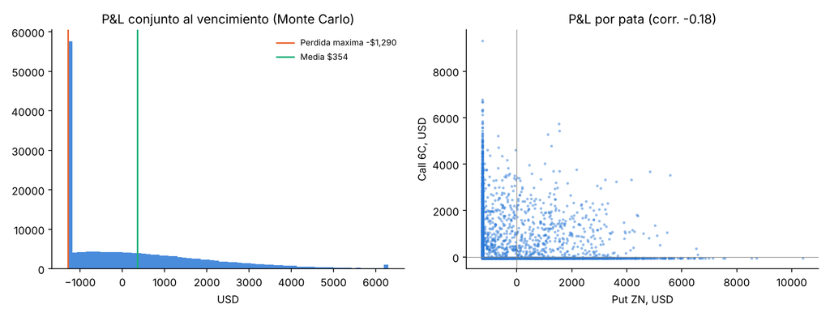

```r
knitr::include_graphics("../Datos/swap_montecarlo.png")
```

Son 200,000 trayectorias con variables antitéticas, correlación de 0.30 entre los retornos de los dos futuros y volatilidades implícitas del 5 de noviembre. La correlación se justifica económicamente: si suben las tasas el ZN cae y el dólar canadiense tiende a caer también, así que los retornos de los futuros se mueven juntos y los P&L de las opciones, en sentido opuesto.

La lectura de la media exige cuidado. El put de ZN pierde en promedio $262: es el **costo esperado del seguro**. El call de 6C gana en promedio $615, pero solo porque su límite (0.00005) está muy por debajo de su valuación: a ese precio el modelo ve una ganancia esperada. Por eso se reporta también el put de ZN solo, que es el costo limpio del seguro. Con la segunda pata la desviación sube de $1,563 a $1,740, pero la probabilidad de ganar pasa de 29.1 % a 48.0 % y la pérdida máxima es de $1,290. Las dos patas tienen sensibilidad inversa (correlación de sus P&L de -0.18): una financia a la otra.

## 7.4 Regímenes

```r
rg <- read.csv("../Datos/swap_regimenes.csv", stringsAsFactors = FALSE)
data.frame(Régimen = rg$regimen, `Put ZN` = usd(rg$put_zn), `Call 6C` = usd(rg$call_6c),
           Total = usd(rg$total), check.names = FALSE)
```

| Régimen | Put ZN | Call 6C | Total |
| --- | --- | --- | --- |
| Reflacion (tasas suben, dolar se debilita: CAD sube) | $3,414 | $2,418 | $5,832 |
| Fed restrictiva (tasas suben, dolar se fortalece: CAD cae) | $3,414 | -$40 | $3,374 |
| Fed acomodaticia (tasas bajan, dolar se debilita: CAD sube) | -$1,250 | $2,418 | $1,168 |
| Aversion al riesgo (tasas bajan, dolar se fortalece: CAD cae) | -$1,250 | -$40 | -$1,290 |

## 7.5 Tickets de la semana (diseño)

| Pata | Instrumento | Contratos | Límite | Prima |
| --- | --- | --- | --- | --- |
| Tasas | Put ZNA6 107.25, vence 9-nov | 5 | 0.25 | $1,250 |
| Divisa | Call 6C66 0.715, vence 9-nov | 8 | 0.00005 | $40 |

La prima total es de $1,290, el 1.27 % de la cuenta de CME ($101,200.63 al 6 de noviembre), y la pérdida máxima es esa misma cifra. Los tickets de confirmación se capturaron el 6 de noviembre a las 2:59 pm (2.40 días para el vencimiento). Se mantienen las cantidades de esos tickets; con una regla de presupuesto por pata ($2,750 y $2,100) y los precios teóricos de Black, el tamaño habría sido de 13 puts de ZN y 25 calls de 6C. Los tickets se capturaron en la pantalla de confirmación y **no se enviaron**: son el diseño ajustado al vencimiento semanal del 9 de noviembre que pidió el profesor, no una posición abierta (`evidencias/capturas/cme/`). Las posiciones ejecutadas son las del ciclo del 5 de noviembre (sección 5), en la cuenta de Eduardo. El límite del call de 6C está en el tick mínimo, por debajo de su valuación teórica.